Álgebra Linear com Python

# A Geometria das Transformações Lineares

#### Dependendo de como encaramos uma n-upla, se como um ponto ou um vetor, o efeito geométrico de um operador $T: R^{n}$ → $R^{n}$ é o de transformar cada ponto (ou vetor) de $R^{n}$ em algum novo ponto (ou vetor).

##### **Referência: Álgebra Linear com aplicações / Anton Howard e Chris Rorres; trad. Claus Ivo Doering. - 8. ed. - Porto Alegre: Bookman, 2001.**

### Reflexões

Considere o operador $T: R^{n}$ → $R^{n}$ que aplica cada vetor na sua imagem simétrica em relação a diferentes eixos. Para conseguir fazer esse processo, vamos utilizar a ideia de **Transformação Linear** para mudar o vetor de uma base para outra, utilizando nossas matrizes de transformações lineares definidas abaixo.

| **Operador** | **Equações** | **Matriz Canônica** |
| --- | --- | --- |
| Reflexão em torno do **eixo y** | $$w_{1} = -x$$ $$w_{2} = y$$ | $\begin{bmatrix} -1 & 0 \\ 0 & 1 \\ \end{bmatrix}$ |
| Reflexão em torno do **eixo x** | $$w_{1} = x$$ $$w_{2} = -y$$ | $\begin{bmatrix} 1 & 0 \\ 0 & -1 \\ \end{bmatrix} $ |
| Reflexão em torno da **reta y = x** | $$w_{1} = y$$ $$w_{2} = x$$ | $\begin{bmatrix} 0 & 1 \\ 1 & 0 \\ \end{bmatrix}$ |

Primeiramente, vamos importar as bibliotecas do Python que serão necessárias ao decorrer do progama:

```python
# importando a biblioteca numpy do Python
import numpy as np
# importando a biblioteca matplotlib do Python
from mpl_toolkits import mplot3d
import matplotlib.pyplot as plt
%matplotlib inline
```

Vamos agora definir uma função que, ao receber um vetor em uma lista e a matriz de transformação adequada, realiza a transformação linear responsável por fazer a reflexão do vetor em questão.

```python
def transformacaoLinear2d(vetor, matriz):

    # definindo as dimensões da figura
    plt.figure(figsize = (10,5))
    # plotando mais de um gráfico na mesma área de trabalho
    # plt.subplot(1 linha, 2 colunas, 1º gráfico)
    plt.subplot(1,2,1)
    # plota o ponto definido para o vetor, esse que parte da origem
    plt.scatter(vetor[0], vetor[1], color = "red", label = "(x,y)")
    # definindo uma lista mais precisa no eixo x para plotar o vetor
    x = [0, vetor[0]]
    # definindo uma lista mais precisa no eixo y para plotar o vetor
    y = [0, vetor[1]]
    # plotando o vetor informado
    plt.plot(x, y, color = "blue", label = "x")
    # adicionando uma grade ao gráfico
    plt.grid(True)
    # removendo a moldura do gráfico
    plt.box(False)
    # adicionando a legenda ao gráfico
    plt.legend()
    # adicionando um título ao gráfico
    plt.title("Antes da Transformação")

    # realizando a mudança de base para o vetor com a matriz de transformação linear
    novoVetor = np.dot(vetor, matriz)

    # plotando mais de um gráfico na mesma área de trabalho
    # plt.subplot(1 linha, 2 colunas, 2º gráfico)
    plt.subplot(1,2,2)
    # plota o ponto definido para o vetor, esse que parte da origem
    plt.scatter(vetor[0], vetor[1], color = "red", label = "(x,y)")
    # plotando o vetor informado
    plt.plot(x, y, color = "blue", label = "x")
    # definindo uma lista mais precisa no eixo x para plotar o novo vetor
    x = [0, novoVetor[0]]
    # definindo uma lista mais precisa no eixo y para plotar o novo vetor
    y = [0, novoVetor[1]]
    # plota o ponto definido para o vetor, esse que parte da origem
    plt.scatter(x, y, color = "yellow", label = "(T(x1),T(y1))")
    #  plotando o vetor obtido
    plt.plot(x, y, color = "brown", label = "w = T(x)")
    # adicionando uma grade ao gráfico
    plt.grid(True)
     # removendo a moldura do gráfico
    plt.box(False)
    # adicionando a legenda ao gráfico
    plt.legend()
    # adicionando um título ao gráfico
    plt.title("Após a Transformação")

    # função não retorna nenhum valor
    return None
```

Vamos agora definir um vetor qualquer, para testarmos as matrizes de transformação.

```python
# definindo um vetor qualquer para utilizarmos no nosso exemplo
vetor2d = [3,4]
```

Por fim, devemos definir as matrizes também em Python para conseguirmos compilar e visualizar as transformações lineares com auxílio da função acima.

```python
# definindo a matriz de reflexão em torno do eixo y
matriz1 = np.array([[-1, 0],
                    [0, 1]])
# definindo a matriz de reflexão em torno do eixo x
matriz2 = np.array([[1, 0],
                    [0, -1]])
# definindo a matriz de reflexão em torno da reta y = x
matriz3 = np.array([[0, 1],
                    [1, 0]])
```

Agora que definimos todo o nosso ambiente de trabalho para realizar as diferentes reflexões em nosso vetor, podemos visualizar o comportamento gráfico das transformações lineares:

#### Reflexão em torno do eixo y

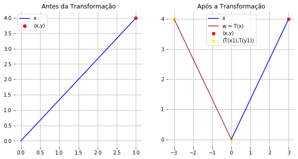

```python
# realizando a transformação linear responsável por fazer uma reflexão em torno do eixo y
transformacaoLinear2d(vetor2d, matriz1)
```

```python
# visualizando o vetor antes da transformação linear
print(vetor2d)
# visualizando o vetor depois da transformação linear
print(np.dot(vetor2d, matriz1))
```

```
[3, 4]
[-3  4]
```

#### Reflexão em torno do eixo x

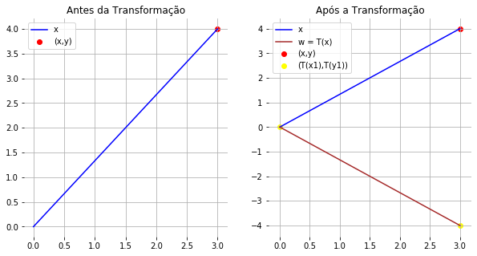

```python
# realizando a transformação linear responsável por fazer uma reflexão em torno do eixo x
transformacaoLinear2d(vetor2d, matriz2)
```

```python
# visualizando o vetor antes da transformação linear
print(vetor2d)
# visualizando o vetor depois da transformação linear
print(np.dot(vetor2d, matriz2))
```

```
[3, 4]
[ 3 -4]
```

#### Reflexão em torno da reta y = x

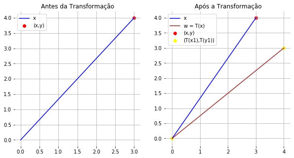

```python
# realizando a transformação linear responsável por fazer uma reflexão em torno da reta y = x
transformacaoLinear2d(vetor2d, matriz3)
```

```python
# visualizando o vetor antes da transformação linear
print(vetor2d)
# visualizando o vetor depois da transformação linear
print(np.dot(vetor2d, matriz3))
```

```
[3, 4]
[4 3]
```

podemos definir as mesmas transformações lineares usando 3 dimensões. Observe as semelhanças com o processo anterior na nova função abaixo.

```python
def transformacaoLinear3d(vetor, matriz):

    # definindo as dimensões da figura
    fig = plt.figure(figsize = (20,10))
    # definindo o ambiente 3d para a plotagem
    ax = plt.axes(projection="3d")
    # plotando mais de um gráfico na mesma área de trabalho
    # plt.subplot(1 linha, 2 colunas, 1º gráfico)
    ax = fig.add_subplot(1, 2, 1, projection='3d')
    # plota o ponto definido para o vetor, esse que parte da origem
    ax.scatter3D(vetor[0], vetor[1], vetor[2], color = "red", label = "(x,y,z)")
    # definindo uma lista mais precisa no eixo x para plotar o vetor
    x = [0, vetor[0]]
    # definindo uma lista mais precisa no eixo y para plotar o vetor
    y = [0, vetor[1]]
    # definindo uma lista mais precisa no eixo z para plotar o vetor
    z = [0, vetor[2]]
    # plotando o vetor informado
    ax.plot3D(x, y, z, color = "blue", label = "x")
    ax.plot3D([0,1], [0,0], [0,0], color = "green")
    ax.plot3D([0,0], [0,1], [0,0], color = "green")
    ax.plot3D([0,0], [0,0], [0,1], color = "green")
    # adicionando uma grade ao gráfico
    plt.grid(True)
    # removendo a moldura do gráfico
    plt.box(False)
    # adicionando a legenda ao gráfico
    plt.legend()
    # adicionando um título ao gráfico
    plt.title("Antes da Transformação")

    # realizando a mudança de base para o vetor com a matriz de transformação linear
    novoVetor = np.dot(vetor, matriz)

    # plotando mais de um gráfico na mesma área de trabalho
    # plt.subplot(1 linha, 2 colunas, 2º gráfico)
    ax = fig.add_subplot(1, 2, 2, projection='3d')
    # plota o ponto definido para o vetor, esse que parte da origem
    ax.scatter3D(vetor[0], vetor[1], vetor[2], color = "red", label = "(x,y,z)")
    # plotando o vetor informado
    ax.plot3D(x, y, z, color = "blue", label = "x")
    # definindo uma lista mais precisa no eixo x para plotar o novo vetor
    x = [0, novoVetor[0]]
    # definindo uma lista mais precisa no eixo y para plotar o novo vetor
    y = [0, novoVetor[1]]
    # definindo uma lista mais precisa no eixo z para plotar o novo vetor
    y = [0, novoVetor[2]]
    # plota o ponto definido para o vetor, esse que parte da origem
    ax.scatter3D(x, y, z, color = "yellow", label = "(T(x1),T(y1), T(z1))")
    #  plotando o vetor obtido
    ax.plot3D(x, y, z, color = "brown", label = "w = T(x)")
    ax.plot3D([0,1], [0,0], [0,0], color = "green")
    ax.plot3D([0,0], [0,1], [0,0], color = "green")
    ax.plot3D([0,0], [0,0], [0,1], color = "green")
    # adicionando uma grade ao gráfico
    plt.grid(True)
     # removendo a moldura do gráfico
    plt.box(False)
    # adicionando a legenda ao gráfico
    plt.legend()
    # adicionando um título ao gráfico
    plt.title("Após a Transformação")
    # função não retorna nenhum valor

    # função não retorna nenhum valor
    return None
```

As matrizes de transformação que serão utilizadas para realizar a reflexão do vetor em 3 dimensões em torno do **plano xy**, **plano xz** e **plano yz**, respectivamente, estão ilustradas abaixo:

[output not shown]

Devemos agora definir um vetor em 3 dimensões e tornar as matrizes acima compiláveis pelo Python:

```python
# definindo um vetor qualquer para utilizarmos no nosso exemplo
vetor3d = [1,2,3]
```

```python
# definindo a matriz de reflexão em torno do plano xy
matriz4 = np.array([[1, 0, 0],
                    [0, 1, 0],
                    [0, 0, -1]])
# definindo a matriz de reflexão em torno do plano xz
matriz5 = np.array([[1, 0, 0],
                    [0, -1, 0],
                    [0, 0, 1]])
# definindo a matriz de reflexão em torno do plano yz
matriz6 = np.array([[-1, 0, 0],
                    [0, 1, 0],
                    [0, 0, 1]])
```

Agora que definimos todo o ambiente de trabalho para realizar as reflexões no vetor, podemos visualizar o compartamento gráfico das transformações lineares:

#### Reflexão em torno do plano xy

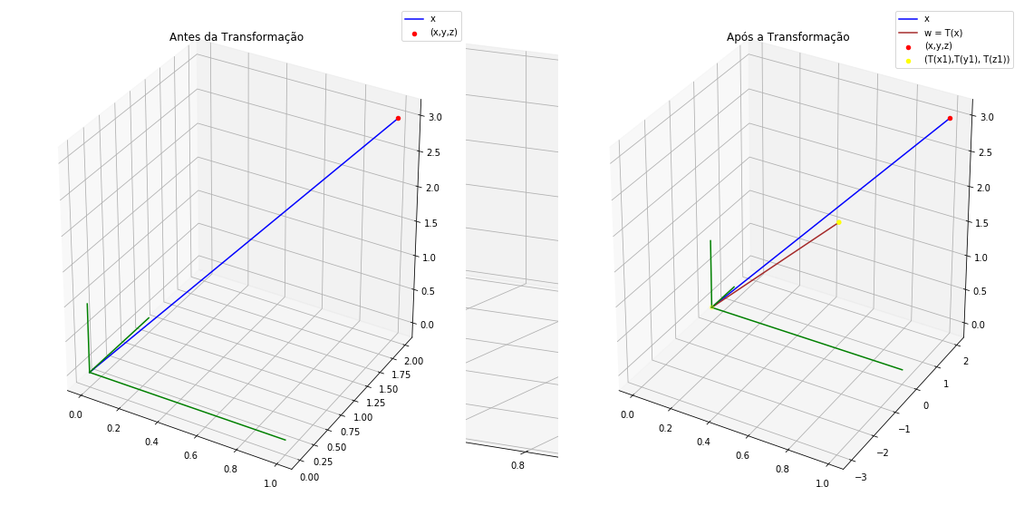

```python
# realizando a transformação linear responsável por fazer uma reflexão em torno do plano xy
transformacaoLinear3d(vetor3d, matriz4)
```

```python
# visualizando o vetor antes da transformação linear
print(vetor3d)
# visualizando o vetor depois da transformação linear
print(np.dot(vetor3d, matriz4))
```

```
[1, 2, 3]
[ 1  2 -3]
```

#### Reflexão em torno do plano xz

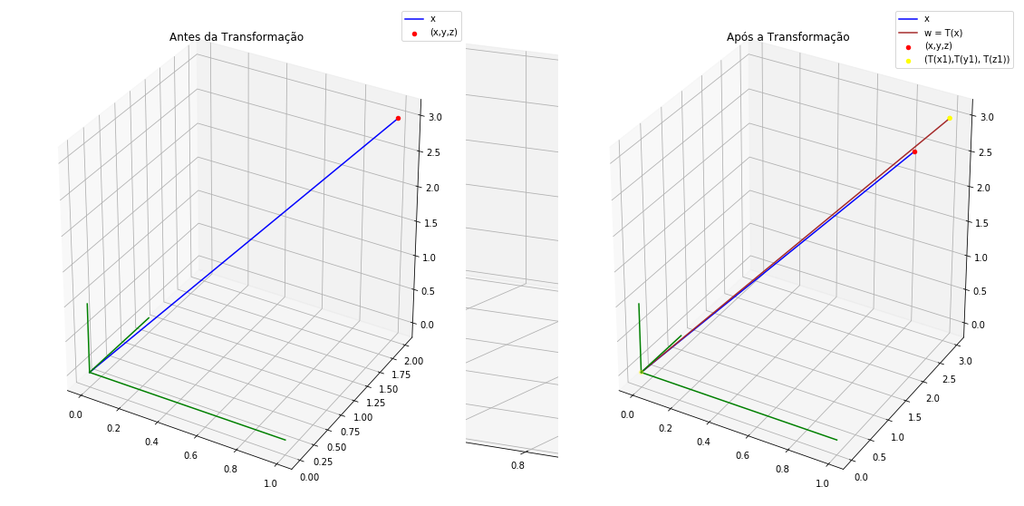

```python
# realizando a transformação linear responsável por fazer uma reflexão em torno do plano xz
transformacaoLinear3d(vetor3d, matriz5)
```

```python
# visualizando o vetor antes da transformação linear
print(vetor3d)
# visualizando o vetor depois da transformação linear
print(np.dot(vetor3d, matriz5))
```

```
[1, 2, 3]
[ 1 -2  3]
```

#### Reflexão em torno do plano yz

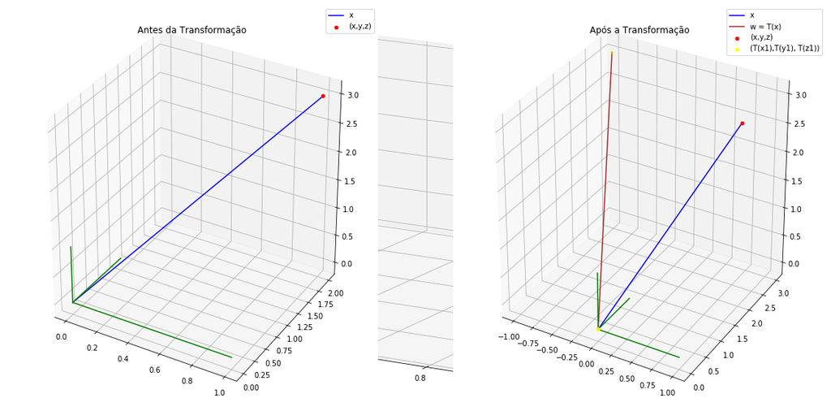

```python
# realizando a transformação linear responsável por fazer uma reflexão em torno do plano yz
transformacaoLinear3d(vetor3d, matriz6)
```

```python
# visualizando o vetor antes da transformação linear
print(vetor3d)
# visualizando o vetor depois da transformação linear
print(np.dot(vetor3d, matriz6))
```

```
[1, 2, 3]
[-1  2  3]
```

### Projeções

Considere o operador $T: R^{n}$ → $R^{n}$ que leva cada vetor na sua **projeção ortogonal** sobre os eixos.

| **Operador** | **Equações** | **Matriz Canônica** |
| --- | --- | --- |
| Projeção ortogonal sobre o **eixo x** | $$w_{1} = x$$ $$w_{2} = 0$$ | $\begin{bmatrix} 1 & 0 \\ 0 & 0 \\ \end{bmatrix}$ |
| Projeção ortogonal sobre o **eixo y** | $$w_{1} = 0$$ $$w_{2} = y$$ | $\begin{bmatrix} 0 & 0 \\ 0 & 1 \\ \end{bmatrix}$ |

Devemos agora definir as matrizes acima compiláveis pelo Python:

```python
# definindo a matriz de transformação para a projeção ortogonal sobre o eixo x
matriz7 = np.array([[1, 0],
                    [0, 0]])
# definindo a matriz de transformação para a projeção ortogonal sobre o eixo y
matriz8 = np.array([[0, 0],
                    [0, 1]])
```

#### Projeção ortogonal no eixo x

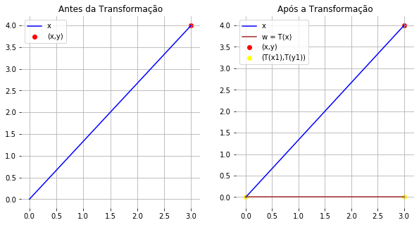

```python
# realizando a transformação linear responsável por fazer uma projeção ortogonal no eixo x
transformacaoLinear2d(vetor2d, matriz7)
```

```python
# visualizando o vetor antes da transformação linear
print(vetor2d)
# visualizando o vetor depois da transformação linear
print(np.dot(vetor2d, matriz7))
```

```
[3, 4]
[3 0]
```

#### Projeção ortogonal no eixo y

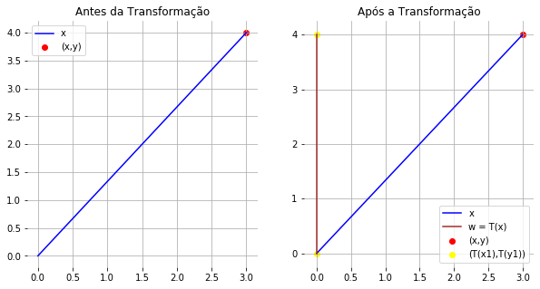

```python
# realizando a transformação linear responsável por fazer uma projeção ortogonal no eixo y
transformacaoLinear2d(vetor2d, matriz8)
```

```python
# visualizando o vetor antes da transformação linear
print(vetor2d)
# visualizando o vetor depois da transformação linear
print(np.dot(vetor2d, matriz8))
```

```
[3, 4]
[0 4]
```

As matrizes de transformação que serão utilizadas para realizar a projeção ortogonal do vetor em 3 dimensões em torno do **plano xy**, **plano xz** e **plano yz**, respectivamente, estão ilustrados abaixo:

| **Operador** | **Equações** | **Matriz Canônica** |
| --- | --- | --- |
| Projeção ortogonal sobre o **plano xy** | $$w_{1} = x$$ $$w_{2} = y$$ $$w_{3} = 0$$ | $\begin{bmatrix} 1 & 0 & 0 \\ 0 & 1 & 0 \\ 0 & 0 & 0 \\ \end{bmatrix}$ |
| Projeção ortogonal sobre o **plano xz** | $$w_{1} = x$$ $$w_{2} = 0$$ $$w_{3} = z$$ | $\begin{bmatrix} 1 & 0 & 0 \\ 0 & 0 & 0 \\ 0 & 0 & 1 \\ \end{bmatrix}$ |
| Projeção ortogonal sobre o **plano yz** | $$w_{1} = 0$$ $$w_{2} = y$$ $$w_{3} = z$$ | $\begin{bmatrix} 0 & 0 & 0 \\ 0 & 1 & 0 \\ 0 & 0 & 1 \\ \end{bmatrix}$ |

Devemos agora definir as matrizes acima compiláveis pelo Python:

```python
# definindo a matriz de transformação para a projeção ortogonal sobre o plano xy
matriz9 = np.array([[1, 0, 0],
                    [0, 1, 0],
                    [0, 0, 0]])
# definindo a matriz de transformação para a projeção ortogonal sobre o plano xz
matriz10 = np.array([[1, 0, 0],
                     [0, 0, 0],
                     [0, 0, 1]])
# definindo a matriz de transformação para a projeção ortogonal sobre o plano yz
matriz11 = np.array([[0, 0, 0],
                     [0, 1, 0],
                     [0, 0, 1]])
```

#### Projeção ortogonal sobre o plano xy

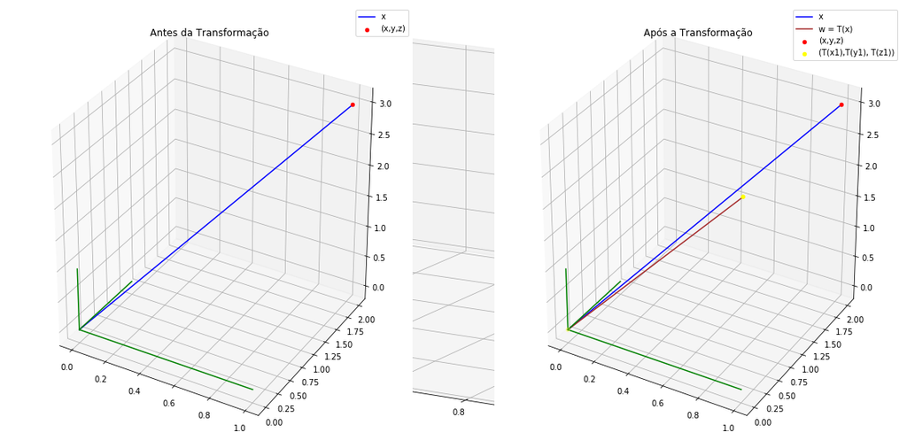

```python
# realizando a transformação linear responsável por fazer uma projeção ortogonal sobre o plano xy
transformacaoLinear3d(vetor3d, matriz9)
```

```python
# visualizando o vetor antes da transformação linear
print(vetor3d)
# visualizando o vetor depois da transformação linear
print(np.dot(vetor3d, matriz9))
```

```
[1, 2, 3]
[1 2 0]
```

#### Projeção ortogonal sobre o plano xz

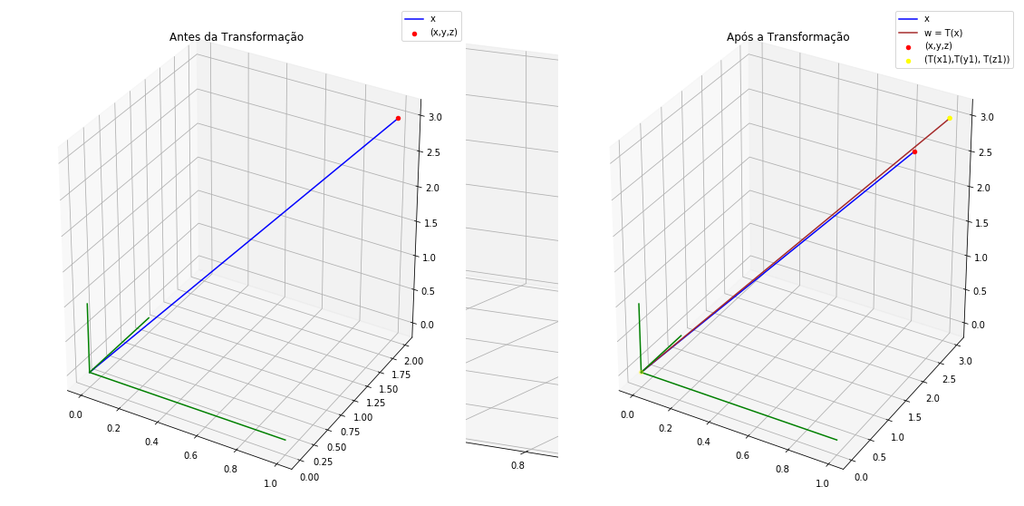

```python
# realizando a transformação linear responsável por fazer uma projeção ortogonal sobre o plano xz
transformacaoLinear3d(vetor3d, matriz10)
```

```python
# visualizando o vetor antes da transformação linear
print(vetor3d)
# visualizando o vetor depois da transformação linear
print(np.dot(vetor3d, matriz10))
```

```
[1, 2, 3]
[1 0 3]
```

#### Projeção ortogonal sobre o plano yz

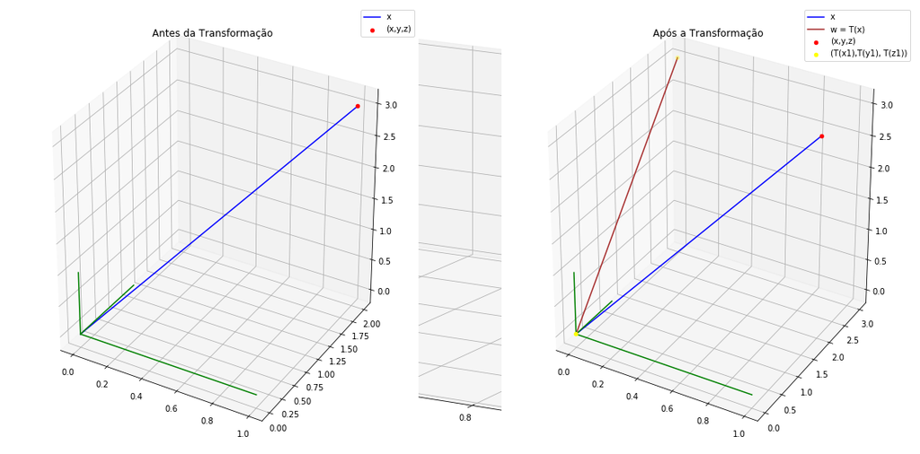

```python
# realizando a transformação linear responsável por fazer uma projeção ortogonal sobre o plano yz
transformacaoLinear3d(vetor3d, matriz11)
```

```python
# visualizando o vetor antes da transformação linear
print(vetor3d)
# visualizando o vetor depois da transformação linear
print(np.dot(vetor3d, matriz11))
```

```
[1, 2, 3]
[0 2 3]
```

### Rotações

Um operador que gira cada vetor em $R^{n}$ por um ângulo fixado θ é chamado uma rotação em $R^{n}$.

| **Operador** | **Equações** | **Matriz Canônica** |
| --- | --- | --- |
| Rotação pelo **ângulo θ** | $$w_{1} = x.cos(t) + y.sen(t)$$ $$w_{2} = -x.sen(t) + y.cos(t)$$ | $\begin{bmatrix} cos(t) & sen(t) \\ -sen(t) & cos(t) \\ \end{bmatrix}$ |

Devemos agora definir um ângulo qualquer (vamos usar 45°) e tornar as matrizes acima compiláveis pelo Python:

```python
# definindo um ângulo de 45° para utilizarmos no nosso exemplo, em radianos
teta = np.pi / 4
```

```python
# definindo a matriz de transformação para a rotação dado um ângulo qualquer
matriz12 = np.array([[np.cos(teta), (np.sin(teta))],
                     [-np.sin(teta), np.cos(teta)]])
```

#### Rotação de um vetor 45º

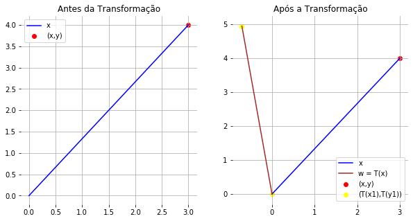

```python
# realizando a transformação linear responsável por fazer uma rotação dado um ângulo teta
transformacaoLinear2d(vetor2d, matriz12)
```

```python
# visualizando o vetor antes da transformação linear
print(vetor2d)
# visualizando o vetor depois da transformação linear
print(np.dot(vetor2d, matriz12))
```

```
[3, 4]
[-0.70710678  4.94974747]
```

Vamos mudar o ângulo θ para 90°:

```python
# definindo um ângulo de 90º para teta, em radianos
teta = np.pi / 2
```

```python
# definindo a matriz de transformação para a rotação dado um ângulo qualquer
matriz12 = np.array([[np.cos(teta), (np.sin(teta))],
                     [-np.sin(teta), np.cos(teta)]])
```

#### Rotação de um vetor 90º

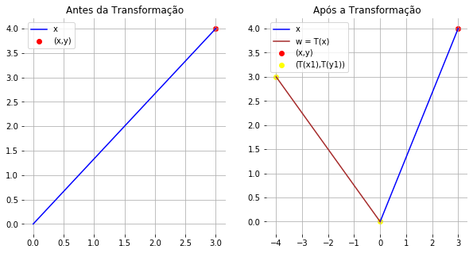

```python
# realizando a transformação linear responsável por fazer uma rotação dado um ângulo teta
transformacaoLinear2d(vetor2d, matriz12)
```

```python
# visualizando o vetor antes da transformação linear
print(vetor2d)
# visualizando o vetor depois da transformação linear
print(np.dot(vetor2d, matriz12))
```

```
[3, 4]
[-4.  3.]
```

As matrizes de transformação que serão utilizadas para realizar as rotações do vetor em 3 dimensões estão ilustradas abaixo:

| **Operador** | **Equações** | **Matriz Canônica** |
| --- | --- | --- |
| Rotação anti-horária em torno do eixo x positivo por um **ângulo θ** | $$w_{1} = x$$ $$w_{2} = y.cos(t) - z.sen(t)$$ $$w_{3} = y.sen(t) + z.cos(t)$$ | $\begin{bmatrix} 1 & 0 & 0 \\ 0 & cos(t) & -sen(t) \\ 0 & sen(t) & cos(t) \\ \end{bmatrix}$ |
| Rotação anti-horária em torno do eixo y positivo por um **ângulo θ** | $$w_{1} = x.cos(t) + z.sen(t)$$ $$w_{2} = y$$ $$w_{3} = -x.sen(t) + z.cos(t)$$ | $\begin{bmatrix} cos(t) & 0 & sen(t) \\ 0 & 1 & 0 \\ -sen(t) & 0 & cos(t) \\ \end{bmatrix}$ |
| Rotação anti-horária em torno do eixo z positivo por um **ângulo θ** | $$w_{1} = x.cos(t) - y.sen(t)$$ $$w_{2} = x.sen(t) + y.cos(t)$$ $$w_{3} = z$$ | $\begin{bmatrix} cos(t) & -sen(t) & 0 \\ sen(t) & cos(t) & 0 \\ 0 & 0 & 1 \\ \end{bmatrix}$ |

Devemos agora definir as matrizes acima compiláveis pelo Python:

```python
# definindo um ângulo de 30º para utilizarmos no nosso exemplo
teta = np.pi / 6
```

```python
# definindo a matriz de transformação para rotação anti-horária em torno do eixo x positivo por um ângulo
# teta
matriz13 = np.array([[1, 0, 0],
                     [0, np.cos(teta), -np.sin(teta)],
                     [0, np.sin(teta), np.cos(teta)]])
# definindo a matriz de transformação para rotação anti-horária em torno do eixo y positivo por um ângulo
# teta
matriz14 = np.array([[np.cos(teta), 0, np.sin(teta)],
                     [0, 1, 0],
                     [-np.sin(teta), 0, np.cos(teta)]])
# definindo a matriz de transformação para rotação anti-horária em torno do eixo z positivo por um ângulo
# teta
matriz15 = np.array([[np.cos(teta), -np.sin(teta), 0],
                     [np.sin(teta), np.cos(teta), 0],
                     [0, 0, 1]])
```

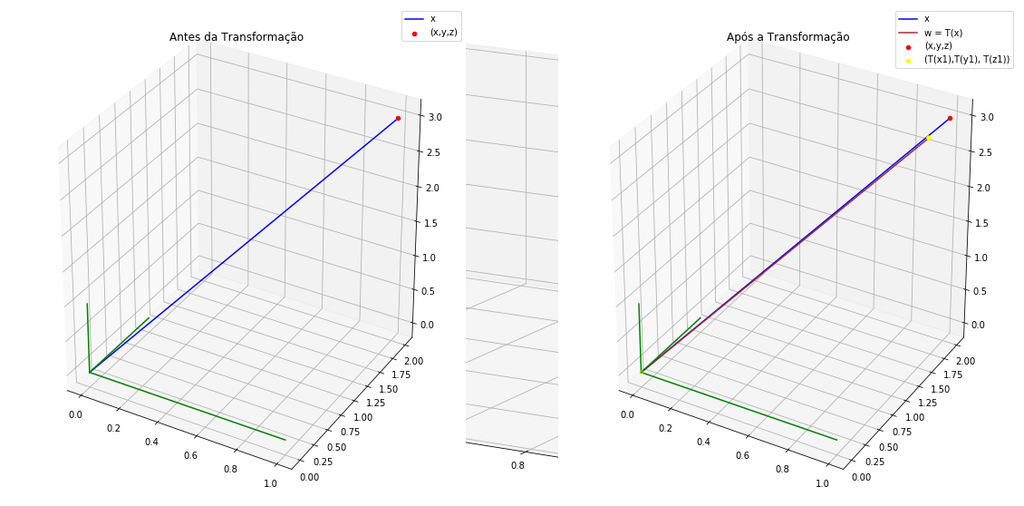

```python
# realizando a transformação linear responsável por fazer uma rotação anti-horária em
# torno do eixo x positivo por um ângulo θ
transformacaoLinear3d(vetor3d, matriz13)
```

```python
# visualizando o vetor antes da transformação linear
print(vetor3d)
# visualizando o vetor depois da transformação linear
print(np.dot(vetor3d, matriz13))
```

```
[1, 2, 3]
[1.         3.23205081 1.59807621]
```

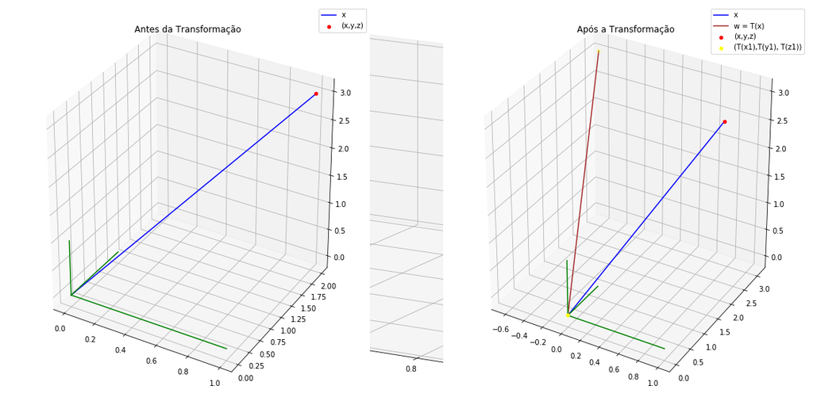

```python
# realizando a transformação linear responsável por fazer uma rotação anti-horária em
# torno do eixo y positivo por um ângulo θ
transformacaoLinear3d(vetor3d, matriz14)
```

```python
# visualizando o vetor antes da transformação linear
print(vetor3d)
# visualizando o vetor depois da transformação linear
print(np.dot(vetor3d, matriz14))
```

```
[1, 2, 3]
[-0.6339746   2.          3.09807621]
```

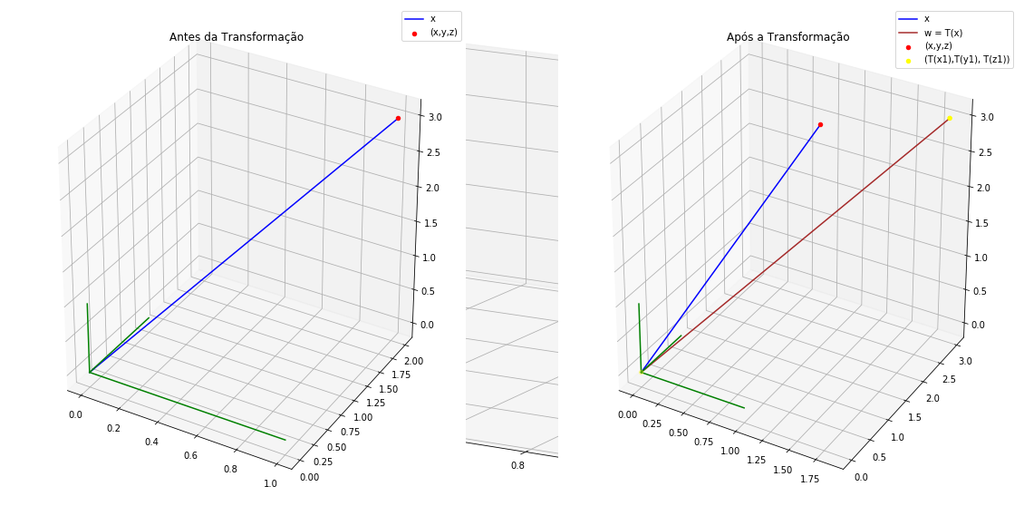

```python
# realizando a transformação linear responsável por fazer uma rotação anti-horária em
# torno do eixo z positivo por um ângulo θ
transformacaoLinear3d(vetor3d, matriz15)
```

```python
# visualizando o vetor antes da transformação linear
print(vetor3d)
# visualizando o vetor depois da transformação linear
print(np.dot(vetor3d, matriz15))
```

```
[1, 2, 3]
[1.8660254  1.23205081 3.        ]
```

### Dilatações e Contrações

Se **k** é um escalar não-negativo, então o operador $T(x) = kx$ de $R^{n}$ é chamado uma **homotetia** de razão k; especificamente, o operador é uma **contração de razão k** se 0 ≤ k ≤ 1 e uma **dilatação de razão k** se k ≥ 1. O efeito geométrico de uma contração é comprimir cada vetor por um fator **k** e o efeito geométrico de uma dilatação é esticar cada vetor por um fator **k**. Uma contração comprime $R^{n}$ uniformemente de todas as direções na direção da origem e uma dilatação expande $R^{n}$ uniformemente em todas as direções para longe da origem. A contração mais extrema ocorre quando **k** = 0, caso em que $T(x) = kx$ reduz ao operador nulo $T(x) = 0$, que comprime cada vetor a um único ponto (a origem). Se k = 1, então $T(x) = kx$ reduz ao operador identidade $T(x) = x$, que deixa cada vetor inalterado; isto poderia ser considerado tanto uma contração quanto uma dilatação.

| **Operador** | **Equações** | **Matriz Canônica** |
| --- | --- | --- |
| Contração de fator k em $R^{2}$ (0 ≤ k ≤ 1) | $$w_{1} = kx$$ $$w_{2} = ky$$ | $\begin{bmatrix} k & 0 \\ 0 & k \\ \end{bmatrix}$ |
| Dilatação de fator k em $R^{2}$ (0 ≥ 1) | $$w_{1} = kx$$ $$w_{2} = ky$$ |  |

Devemos agora defininir um valor para k, e tornar as matrizes acima compiláveis pelo Python:

```python
# definindo um valor para k de contração
k = 0.75
```

```python
# definindo a matriz de transformação para dilatações e contrações de vetores
matriz16 = np.array([[k, 0],
                     [0, k]])
```

#### Contração de um vetor quando k = 0.75

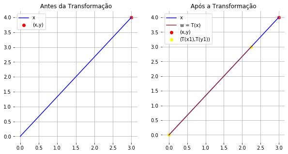

```python
# realizando a transformação linear responsável por fazer uma contração no vetor
transformacaoLinear2d(vetor2d, matriz16)
```

```python
# visualizando o vetor antes da transformação linear
print(vetor2d)
# visualizando o vetor depois da transformação linear
print(np.dot(vetor2d, matriz16))
```

```
[3, 4]
[2.25 3.  ]
```

```python
# definindo um vetor qualquer para utilizarmos no nosso exemplo
vetor = [2,2]
# definindo um valor para k de dilatação
k = 2
```

```python
# definindo a matriz de transformação para dilatações e contrações de vetores
matriz16 = np.array([[k, 0],
                     [0, k]])
```

#### Dilatação de um vetor quando k = 2

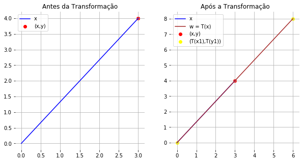

```python
# realizando a transformação linear responsável por fazer uma dilatação no vetor
transformacaoLinear2d(vetor2d, matriz16)
```

```python
# visualizando o vetor antes da transformação linear
print(vetor2d)
# visualizando o vetor depois da transformação linear
print(np.dot(vetor2d, matriz16))
```

```
[3, 4]
[6 8]
```

As matrizes de transformação que serão utilizadas para realizar as contrações e dilatações do nosso vetor em 3 dimensões estão ilustradas abaixo:

| **Operador** | **Equações** | **Matriz Canônica** |
| --- | --- | --- |
| Contração de fator k em $R^{3}$ (0 ≤ k ≤ 1) | $$w_{1} = kx$$ $$w_{2} = ky$$ $$w_{3} = kz$$ | $\begin{bmatrix} k & 0 & 0 \\ 0 & k & 0 \\ 0 & 0 & k \\ \end{bmatrix}$ |
| Dilatação de fator k em $R^{3}$ (k ≥ 1) | $$w_{1} = kx$$ $$w_{2} = ky$$ $$w_{3} = kz$$ |  |

Devemos agora tornar as matrizes acima compiláveis pelo Python:

```python
# definindo um valor de contração para k
k = 0.25
```

```python
# definindo a matriz de transformação para dilatações e contrações de vetores
matriz17 = np.array([[k, 0, 0],
                     [0, k, 0],
                     [0, 0, k]])
```

#### Contração de um vetor quando k = 0.25

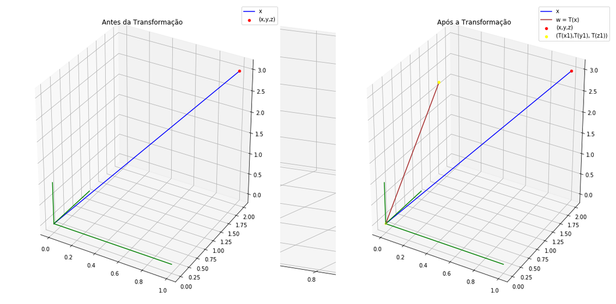

```python
# realizando a transformação linear responsável por fazer uma contração no vetor
transformacaoLinear3d(vetor3d, matriz17)
```

```python
# visualizando o vetor antes da transformação linear
print(vetor3d)
# visualizando o vetor depois da transformação linear
print(np.dot(vetor3d, matriz17))
```

```
[1, 2, 3]
[0.25 0.5  0.75]
```

```python
# definindo um vetor qualquer para utilizarmos no nosso exemplo
vetor = [2,2,2]
# definindo um valor de dilatação para k
k = 2
```

```python
# definindo a matriz de transformação para dilatações e contrações de vetores
matriz17 = np.array([[k, 0, 0],
                     [0, k, 0],
                     [0, 0, k]])
```

#### Dilatação de um vetor quando k = 2

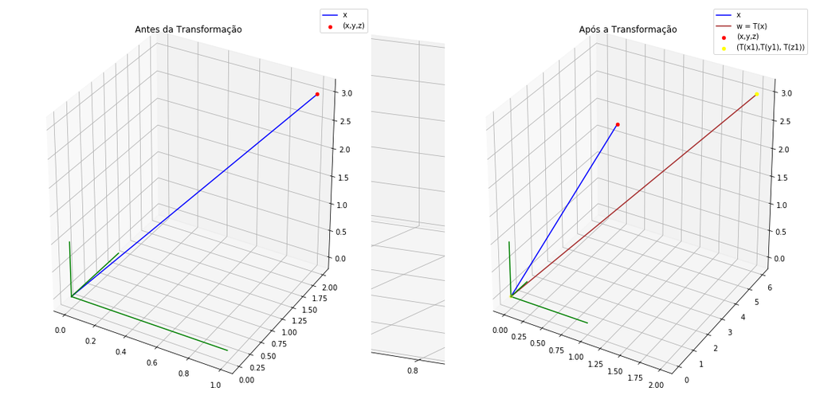

```python
# realizando a transformação linear responsável por fazer uma contração no vetor
transformacaoLinear3d(vetor3d, matriz17)
```

```python
# visualizando o vetor antes da transformação linear
print(vetor3d)
# visualizando o vetor depois da transformação linear
print(np.dot(vetor3d, matriz17))
```

```
[1, 2, 3]
[2 4 6]
```

### Alguma Dúvida? Entre em Contato Comigo:

- Me envie um e-mail;